# Homework 4: Logistic regression and judges

Nick Fox

Due: Sunday, April 19, 2015

This assignment is based on an assignment created by [German Rodriguez](http://data.princeton.edu/wws509/sets/set3.html). Topics covered include:

- reading in tabular data
- ggplot2
- logistic regression

For this assignment you will be extending the analysis in this article:

Greene and Schaffer (1992) [“Leave to Appeal and Leave to Commence Judicial Review in Canada’s Refugee-Determination System: Is the Process Fair?”](http://yorkspace.library.yorku.ca/xmlui/handle/10315/7864) International Journal of Refugee Law, 4.1: 71-83.

Here’s how the authors describe the paper: “The purpose of this study is to determine whether refugees and other persons who are applying for leave to appeal a decision of the Convention Refugee Determination Division of the Canadian Immigration and Refugee Board, a decision of the Appeal Division of the Immigration and Refugee Board, or to commence an action for judicial review have a relatively equal chance to convince the Federal Court of Appeal of the merits of their applications.”"

The data and [documentation](http://socserv.mcmaster.ca/jfox/Books/Applied-Regression-2E/datasets/Greene.pdf) were made avaialble by John Fox. I have stored a copy of the data in Greene.txt in the subfolder data.

```r
suppressPackageStartupMessages(require(dplyr))
suppressPackageStartupMessages(require(ggplot2))
suppressPackageStartupMessages(require(broom))

data <- read.table("data/Greene.txt")
```

Before doing anything else, just play with the data to get a sense of it.

```r
data %>%
  group_by(decision) %>%
  summarise(mean_decision = mean(decision))
```

```
## Source: local data frame [2 x 2]
##
##   decision mean_decision
## 1       no             1
## 2      yes             2
```

```r
# "no" is dummy coded as 1, "yes" is dummy coded as 2

data %>%
  group_by(decision) %>%
  summarise(n_decision = n())
```

```
## Source: local data frame [2 x 2]
##
##   decision n_decision
## 1       no        270
## 2      yes        114
```

```r
#270 no, 114 yes

data %>%
  group_by(language) %>%
summarise(n_language = n())
```

```
## Source: local data frame [2 x 2]
##
##   language n_language
## 1  English        253
## 2   French        131
```

```r
#253 English, 131 French
```

1. The main outcome of interest is *decision* which records whether the judge granted an appeal or not. In what proprotion of cases did the judge grant an appeal.

```r
decision <- data %>%
  group_by(decision) %>%
  summarise(n_decision = n()) %>%
  mutate(prop_decision = (n_decision / sum(n_decision) * 100))

print(decision)
```

```
## Source: local data frame [2 x 3]
##
##   decision n_decision prop_decision
## 1       no        270       70.3125
## 2      yes        114       29.6875
```

```r
# Judges granted an appeal in 29.69% of cases.
```

2. There are 12 (actually 10) different judges in the data. A key question is whether different judges have different rates of granting an appeal. Make a plot showing the number of cases per judge.

```r
data %>%
  group_by(judge) %>%
  summarise(judge_count = n_distinct(judge))
```

```
## Source: local data frame [10 x 2]
##
##         judge judge_count
## 1  Desjardins           1
## 2       Heald           1
## 3    Hugessen           1
## 4   Iacobucci           1
## 5   MacGuigan           1
## 6     Mahoney           1
## 7     Marceau           1
## 8      Pratte           1
## 9       Stone           1
## 10       Urie           1
```

```r
data_case <- data %>%
  group_by(judge) %>%
  summarise(judge_case = n()) %>%
  arrange(desc(judge_case))

print(data_case)
```

```
## Source: local data frame [10 x 2]
##
##         judge judge_case
## 1   MacGuigan         70
## 2    Hugessen         62
## 3  Desjardins         46
## 4      Pratte         42
## 5       Heald         36
## 6       Stone         33
## 7     Mahoney         30
## 8   Iacobucci         29
## 9     Marceau         25
## 10       Urie         11
```

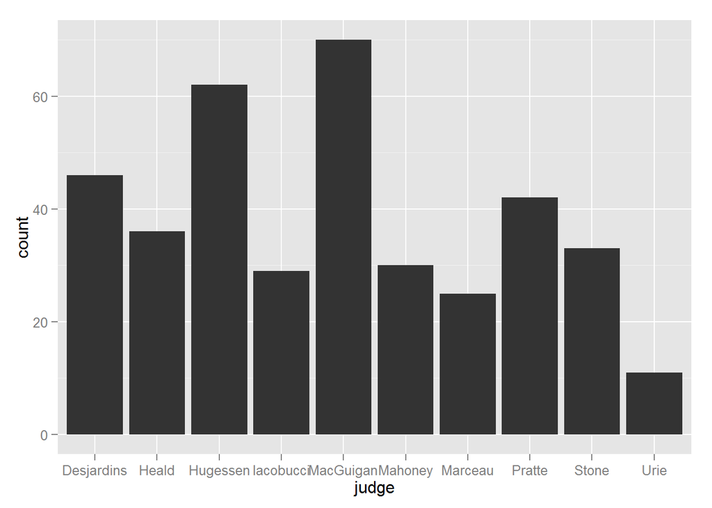

```r
data %>%
  ggplot(aes(x = judge)) + geom_bar()
```

3. Now plot the rate at which the judges grant appeals.

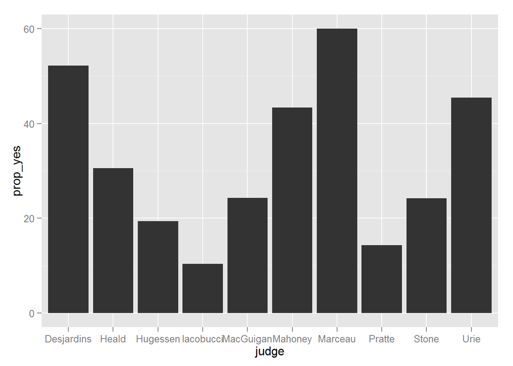

```r
decision_judge <- data %>%
  group_by(judge, decision) %>%
  summarise(n_decision = n()) %>%
  mutate(prop_yes = (n_decision / sum(n_decision) * 100)) %>%
  filter(decision == "yes")

decision_judge %>%
  ggplot(aes(x = judge, y = prop_yes)) + geom_bar(stat = "identity")
```

4. Now let’s try this with logistic regression because we are going to move to more complicated models. Fit a logistic regression predicting whether an appeal will be granted using judge as a categorical predictor. Use Iacobucci as the reference judge to facilitate the comparisons that follow. For more on how to control the reference level of a factor, check out this post on StackOverflow: http://stackoverflow.com/questions/3872070/how-to-force-r-to-use-a-specified-factor-level-as-reference-in-a-regression

```r
data <- within(data, judge <- relevel(judge, ref = "Iacobucci"))

mylogit1 <- glm(decision ~ judge, data = data, family = "binomial")

summary(mylogit1)
```

```
##
## Call:
## glm(formula = decision ~ judge, family = "binomial", data = data)
##
## Deviance Residuals:
##     Min       1Q   Median       3Q      Max
## -1.3537  -0.7459  -0.6559   1.1407   2.1301
##
## Coefficients:
##                 Estimate Std. Error z value Pr(>|z|)
## (Intercept)      -2.1595     0.6097  -3.542 0.000397 ***
## judgeDesjardins   2.2465     0.6774   3.316 0.000912 ***
## judgeHeald        1.3385     0.7090   1.888 0.059038 .
## judgeHugessen     0.7324     0.6893   1.063 0.287993
## judgeMacGuigan    1.0224     0.6704   1.525 0.127245
## judgeMahoney      1.8912     0.7124   2.655 0.007937 **
## judgeMarceau      2.5649     0.7338   3.496 0.000473 ***
## judgePratte       0.3677     0.7525   0.489 0.625057
## judgeStone        1.0200     0.7326   1.392 0.163830
## judgeUrie         1.9772     0.8593   2.301 0.021399 *
## ---
## Signif. codes:  0 '***' 0.001 '**' 0.01 '*' 0.05 '.' 0.1 ' ' 1
##
## (Dispersion parameter for binomial family taken to be 1)
##
##     Null deviance: 467.09  on 383  degrees of freedom
## Residual deviance: 426.69  on 374  degrees of freedom
## AIC: 446.69
##
## Number of Fisher Scoring iterations: 4
```

5. Using the results of the model calculate the predicted probability that Judge Marceau will grant an appeal.

```r
estimates <- coef(mylogit1)

prob_Marceau <- 1 / (1 + exp( - (estimates[1] + estimates[7] * 1)))

print(prob_Marceau)
```

```
## (Intercept)
##         0.6
```

```r
#predicted probability of Judge Marceau granting an appeal is 0.6 (matches the observed value).
```

6. Perhaps the different judges have different types of cases. That might be why they seem to be making such different decisions. Fit a model treating judge as a factor plus the following predictors: (i) an indicator for whether the expert rater thought the case had merit, (ii) location indicators using ‘other’ as the reference category, (iii) a language dummy with French as omitted category. Note that as above you might have to relevel the factors to get this to work as you want.

```r
data %>%
  group_by(rater) %>%
  summarise(mean_rater = mean(rater))
```

```
## Source: local data frame [2 x 2]
##
##   rater mean_rater
## 1    no          1
## 2   yes          2
```

```r
# "no" is coded as 1, "yes" is coded as 2

data %>%
  group_by(language) %>%
  summarise(mean_language = mean(language))
```

```
## Source: local data frame [2 x 2]
##
##   language mean_language
## 1  English             1
## 2   French             2
```

```r
# "English" is coded as 1, "French" is coded as 2


data <- within(data,
  location <- relevel(location, ref = "other")) #relevel factors
data <- within(data,
  language <- relevel(language, ref = "French")) #relevel factors

mylogit2 <- glm(decision ~ judge + rater + location + language,
  data = data, family = "binomial")

summary (mylogit2)
```

```
##
## Call:
## glm(formula = decision ~ judge + rater + location + language,
##     family = "binomial", data = data)
##
## Deviance Residuals:
##     Min       1Q   Median       3Q      Max
## -1.7634  -0.7828  -0.4527   0.9338   2.1890
##
## Coefficients:
##                  Estimate Std. Error z value Pr(>|z|)
## (Intercept)       -3.1099     0.8822  -3.525 0.000423 ***
## judgeDesjardins    2.5119     0.7135   3.520 0.000431 ***
## judgeHeald         1.3289     0.7348   1.808 0.070547 .
## judgeHugessen      1.2372     0.7560   1.637 0.101721
## judgeMacGuigan     1.3108     0.7030   1.865 0.062237 .
## judgeMahoney       1.7327     0.7400   2.341 0.019213 *
## judgeMarceau       3.4304     0.8025   4.274 1.92e-05 ***
## judgePratte        0.6971     0.7892   0.883 0.377103
## judgeStone         0.9768     0.7583   1.288 0.197659
## judgeUrie          2.3313     0.8969   2.599 0.009341 **
## rateryes           1.4247     0.2611   5.457 4.84e-08 ***
## locationMontreal  -0.4276     0.6159  -0.694 0.487500
## locationToronto    0.1030     0.3672   0.280 0.779150
## languageEnglish    0.3268     0.5581   0.586 0.558087
## ---
## Signif. codes:  0 '***' 0.001 '**' 0.01 '*' 0.05 '.' 0.1 ' ' 1
##
## (Dispersion parameter for binomial family taken to be 1)
##
##     Null deviance: 467.09  on 383  degrees of freedom
## Residual deviance: 390.20  on 370  degrees of freedom
## AIC: 418.2
##
## Number of Fisher Scoring iterations: 4
```

```r
estimates2 <- coef(mylogit2)
```

7. For a case that was ruled to have merit, that took place in Toronto, and that was in English, what is the predicted probability that Judge Marceau will grant the appeal?

```r
prob_Marceau2 <- 1 / (1 + exp( - (estimates2[1] + estimates2[7] * 1 +
  estimates2[11] * 1 + estimates2[13] * 1 + estimates2[14] * 1)))

print(prob_Marceau2)
```

```
## (Intercept)
##   0.8979792
```

```r
#The predicted probability of Judge Marceau granting an appeal for a case ruled to have merit, in Toronto, and in English is 0.90.
```